# JLW 6040 Extra Credit Project

Predicting NBA All Star Teams for the 2020-2021 NBA Seasons

First we need to import and clean the data

```python
import pandas as pd
import seaborn as sns
import matplotlib.pyplot as plt
import numpy as np
from IPython.display import display, Math
from sklearn.model_selection import train_test_split

%matplotlib inline

import matplotlib as mpl
mpl.rc("savefig", dpi=100) # Adjust for higher-resolution figures
```

```python
df = pd.read_csv("NBA.csv", sep = ",")

df.head(10)
```

[output not shown]

This looks good, but we should remove the extra stuff from the name column. We can write a function for that then use apply. Also some guys played on multiple teams, so we will need to take their total averages. We will remove names that are duplicates and team does not equal TOT (total).

```python
def clean_name(string):
    stripped = string.split("\\", 1)[0]
    return stripped
df["Player"] = df["Player"].apply(clean_name)
#marks all duplicates as true
mask = ~df["Player"].duplicated(keep = False)
df = df[(mask) | (df["Tm"] == "TOT")]
df.head(10)
```

|  | Rk | Player | Pos | Age | Tm | G | GS | MP | FG | FGA | ... | ORB | DRB | TRB | AST | STL | BLK | TOV | PF | PTS | ASG |
| --- | --- | --- | --- | --- | --- | --- | --- | --- | --- | --- | --- | --- | --- | --- | --- | --- | --- | --- | --- | --- | --- |
| 0 | 1 | Precious Achiuwa | PF | 21 | MIA | 61 | 4 | 12.1 | 2.0 | 3.7 | ... | 1.2 | 2.2 | 3.4 | 0.5 | 0.3 | 0.5 | 0.7 | 1.5 | 5.0 | 0 |
| 1 | 2 | Jaylen Adams | PG | 24 | MIL | 7 | 0 | 2.6 | 0.1 | 1.1 | ... | 0.0 | 0.4 | 0.4 | 0.3 | 0.0 | 0.0 | 0.0 | 0.1 | 0.3 | 0 |
| 2 | 3 | Steven Adams | C | 27 | NOP | 58 | 58 | 27.7 | 3.3 | 5.3 | ... | 3.7 | 5.2 | 8.9 | 1.9 | 0.9 | 0.7 | 1.3 | 1.9 | 7.6 | 0 |
| 3 | 4 | Bam Adebayo | C | 23 | MIA | 64 | 64 | 33.5 | 7.1 | 12.5 | ... | 2.2 | 6.7 | 9.0 | 5.4 | 1.2 | 1.0 | 2.6 | 2.3 | 18.7 | 0 |
| 4 | 5 | LaMarcus Aldridge | C | 35 | TOT | 26 | 23 | 25.9 | 5.4 | 11.4 | ... | 0.7 | 3.8 | 4.5 | 1.9 | 0.4 | 1.1 | 1.0 | 1.8 | 13.5 | 0 |
| 7 | 6 | Ty-Shon Alexander | SG | 22 | PHO | 15 | 0 | 3.1 | 0.2 | 0.8 | ... | 0.1 | 0.5 | 0.7 | 0.4 | 0.0 | 0.1 | 0.2 | 0.1 | 0.6 | 0 |
| 8 | 7 | Nickeil Alexander-Walker | SG | 22 | NOP | 46 | 13 | 21.9 | 4.2 | 10.0 | ... | 0.3 | 2.8 | 3.1 | 2.2 | 1.0 | 0.5 | 1.5 | 1.9 | 11.0 | 0 |
| 9 | 8 | Grayson Allen | SG | 25 | MEM | 50 | 38 | 25.2 | 3.5 | 8.3 | ... | 0.4 | 2.8 | 3.2 | 2.2 | 0.9 | 0.2 | 1.0 | 1.4 | 10.6 | 0 |
| 10 | 9 | Jarrett Allen | C | 22 | TOT | 63 | 45 | 29.6 | 4.7 | 7.7 | ... | 3.1 | 6.9 | 10.0 | 1.7 | 0.5 | 1.4 | 1.6 | 1.5 | 12.8 | 0 |
| 13 | 10 | Al-Farouq Aminu | PF | 30 | TOT | 23 | 14 | 18.9 | 1.7 | 4.3 | ... | 1.0 | 3.8 | 4.8 | 1.3 | 0.8 | 0.4 | 1.2 | 1.3 | 4.4 | 0 |

10 rows × 31 columns

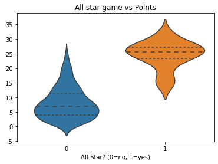

```python
rmv = list(df.columns)
rmv.remove("ASG")
rmv.remove("PTS")
df1 = df.drop(columns = rmv)
ax = sns.violinplot(x="ASG", y="PTS",
                    data=df1, inner="quart")
ax.set(xlabel="All-Star? (0=no, 1=yes)",
       ylabel="",
       title="All star game vs Points");
```

We can see that players on the All Star team have more points on average than players that do not.

```python
import statsmodels.api as sm
df.replace(-np.inf, np.nan)
df.dropna(inplace = True)
cols = list(df.columns)
#need to remove non-predictive variables
cols.remove("ASG")
cols.remove("Rk")
cols.remove("Player")
cols.remove("Pos")
cols.remove("Age")
cols.remove("Tm")
#We also should remove variables that are highly correlated to eliminate multicolinearity
cols.remove("GS")
cols.remove("FGA")
cols.remove("3PA")
cols.remove("2PA")
cols.remove("FTA")
cols.remove("TRB")



X = df[cols]
y = df[["ASG"]]

log_mod=sm.Logit(y.astype(float),X.astype(float)).fit()

print(log_mod.summary2())
#Lets run it again removed variables that do not predict ASG selections well
cols.remove("PF")
cols.remove("BLK")
cols.remove("AST")
cols.remove("3P%")
X = df[cols]

log_mod=sm.Logit(y.astype(float),X.astype(float)).fit()

print(log_mod.summary2())
```

```
Optimization terminated successfully.
         Current function value: 0.043600
         Iterations 13
                         Results: Logit
=================================================================
Model:              Logit            Pseudo R-squared: 0.792
Dependent Variable: ASG              AIC:              81.8615
Date:               2021-12-03 18:08 BIC:              162.0527
No. Observations:   503              Log-Likelihood:   -21.931
Df Model:           18               LL-Null:          -105.23
Df Residuals:       484              LLR p-value:      4.2297e-26
Converged:          1.0000           Scale:            1.0000
No. Iterations:     13.0000
------------------------------------------------------------------
           Coef.    Std.Err.     z     P>|z|     [0.025    0.975]
------------------------------------------------------------------
G           0.1058    0.0505   2.0966  0.0360     0.0069    0.2047
MP         -0.7160    0.2558  -2.7987  0.0051    -1.2174   -0.2146
FG         31.2935   17.6259   1.7754  0.0758    -3.2526   65.8396
FG%       130.0555   63.1476   2.0595  0.0394     6.2885  253.8224
3P         51.7915   19.7596   2.6211  0.0088    13.0634   90.5196
3P%         3.0577    6.1005   0.5012  0.6162    -8.8990   15.0143
2P         22.7101   11.8496   1.9165  0.0553    -0.5146   45.9349
2P%       -52.5595   20.8213  -2.5243  0.0116   -93.3684  -11.7505
eFG%      -74.7181   45.6918  -1.6353  0.1020  -164.2725   14.8363
FT         26.9777   10.5350   2.5608  0.0104     6.3295   47.6258
FT%       -12.9912    5.8586  -2.2174  0.0266   -24.4740   -1.5085
ORB        -3.0382    1.5508  -1.9590  0.0501    -6.0778    0.0014
DRB         1.5777    0.5983   2.6368  0.0084     0.4050    2.7505
AST         0.0843    0.3861   0.2184  0.8271    -0.6724    0.8411
STL         3.8194    1.7408   2.1941  0.0282     0.4075    7.2313
BLK         0.7825    1.6784   0.4662  0.6411    -2.5070    4.0720
TOV        -1.6714    1.1489  -1.4548  0.1457    -3.9232    0.5804
PF         -0.1870    1.0715  -0.1746  0.8614    -2.2871    1.9131
PTS       -25.9590   10.2725  -2.5270  0.0115   -46.0927   -5.8254
=================================================================

Optimization terminated successfully.
         Current function value: 0.043977
         Iterations 12
```

[output cut: 14 more lines]

```
MP         -0.6871    0.2390  -2.8745  0.0040    -1.1555   -0.2186
FG         34.3172   16.1379   2.1265  0.0335     2.6874   65.9470
FG%       126.8257   54.5391   2.3254  0.0201    19.9310  233.7205
3P         52.1712   19.2143   2.7152  0.0066    14.5119   89.8305
2P         21.9587   11.3911   1.9277  0.0539    -0.3675   44.2848
2P%       -52.2170   19.7353  -2.6459  0.0081   -90.8976  -13.5364
eFG%      -69.4444   37.8605  -1.8342  0.0666  -143.6496    4.7608
FT         28.2456   10.0380   2.8139  0.0049     8.5715   47.9196
FT%       -13.5726    5.6424  -2.4055  0.0162   -24.6315   -2.5138
ORB        -3.2975    1.4296  -2.3065  0.0211    -6.0995   -0.4955
DRB         1.6652    0.5553   2.9985  0.0027     0.5768    2.7537
STL         3.8483    1.4961   2.5723  0.0101     0.9161    6.7805
TOV        -1.7876    0.9526  -1.8765  0.0606    -3.6547    0.0795
PTS       -27.1161    9.7998  -2.7670  0.0057   -46.3234   -7.9088
=================================================================
```

```python
#Would not run too many iterations

# from sklearn.linear_model import LogisticRegression
# from sklearn import metrics

# X_train, X_test, y_train,y_test = train_test_split(X, y, test_size = 0.2, random_state = 0)
# log_reg = LogisticRegression()
# log_reg.fit(X_train, y_train)
```

[output not shown]

Conclusion: We found good predictors to predict which players will make the all star team.

We found variables we needed to remove that wre not good predictors. Some were surprising as Assists is a pretty important statistic.

Some problems I ran into were players who did not shoot 3 point shots leaving blanks in the data set. To fix this we removed them as all of the all stars had all stats filled out.

Suggestions for future research would be to utilize a bigger data set with some recent years. We could not go back too far as the parameters fro making the team have changed. Additionally, we could try different variables that could also have predictive power. We could also perform a similar analysis for other nba awards and see the correlation with this model.